# Gov1005: Problem Set 2

Rebecca Xi

2/12/2020

## Mad Libs

1. The earliest date for an endorsement in the dataset is 2017-07-28.
2. The most recent date for an endorsement is 2019-07-29.
3. Steve Adler is the mayor that has endorsed Pete Buttigieg.
4. Endorsers from New Hampshire have an average of 2.6 endorsement points.
5. Between them, the two female candidates who remain in the race (Amy Klobuchar and Elizabeth Warren) have a total of 72 endorsement points.
6. The type of data you are working with (words, numbers, categories, or fancier data types like dates) determines what kinds of operations you can perform on it. To distinguish different types of data, it’s useful to use the function class(). This function allows you to get to know what kind of data you’re working with.
   1. The variable “position” is a factor class of variable.
   2. The variable “endorser” is a character class of variable.
   3. The variable “points” is a numeric class of variable.

## Put It Into Practice

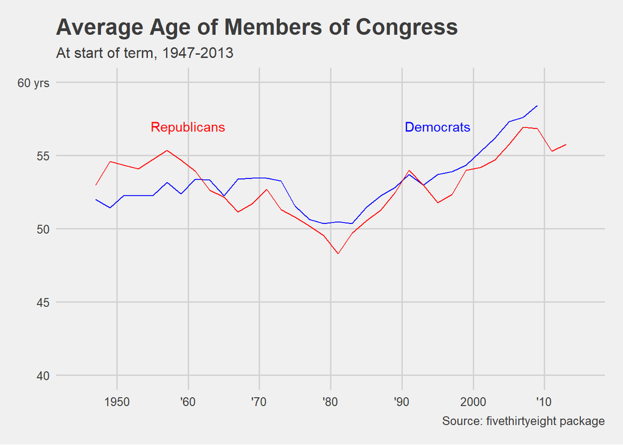

### Colleagues:

- Grace Pan
- John Morse
- Rachel Auslander
- Will Scherpferman
- Evelyn Cai